# Google_Price_Predictor

### Google Stock Price Predictor

This project uses machine learning, specifically LSTM (Long short-term memory) neural networks to predict the price of Google's closing price at the end of a trading day. The model is trained on historical data of Google's closing price. First a benchmark linear regression line is used to see how well the data fits within a linear dimmentsion. Since stocks do not move in a linear fashion a LSTM model is used which effectively creates a moving average for the data used to train the model.

By: Uzoma Nwanna

```python
!pip install --upgrade pandas
!pip install --upgrade pandas-datareader
```

[output not shown]

## Get the Data

**Step 1 :** Define a function to get historical data from yahoo, save in a csv file and store in a dataframe.

```python
import math
import pandas_datareader as web
import numpy as np
import pandas as pd
import datetime

def get_historical_data(symbol,start_date,end_date):
    ''' Daily quotes from Google. Date format='yyyy-mm-dd' '''
    symbol = symbol.upper()
    col_names = ['Date','Open','High','Low','Close','Volume']

    df = web.DataReader(symbol,data_source='yahoo',start=start_date ,end=end_date)
    return df
```

```python
data = get_historical_data('GOOGL','2005-01-01','2017-06-30') # from January 1, 2005 to June 30, 2017
data.to_csv('google.csv',index = False)
```

## Preprocess the data

Now it is time to preprocess the data. In the following cells we will normalise it for better prediction of data.

**Step 1 :** Get the data from csv file.

```python
data = pd.read_csv('google.csv')
print(data.head())

print("\n")
print("Open   --- mean :", np.mean(data['Open']),  "  \t Std: ", np.std(data['Open']),  "  \t Max: ", np.max(data['Open']),  "  \t Min: ", np.min(data['Open']))
print("High   --- mean :", np.mean(data['High']),  "  \t Std: ", np.std(data['High']),  "  \t Max: ", np.max(data['High']),  "  \t Min: ", np.min(data['High']))
print("Low    --- mean :", np.mean(data['Low']),   "  \t Std: ", np.std(data['Low']),   "  \t Max: ", np.max(data['Low']),   "  \t Min: ", np.min(data['Low']))
print("Close  --- mean :", np.mean(data['Close']), "  \t Std: ", np.std(data['Close']), "  \t Max: ", np.max(data['Close']), "  \t Min: ", np.min(data['Close']))
print("Volume --- mean :", np.mean(data['Volume']),"  \t Std: ", np.std(data['Volume']),"  \t Max: ", np.max(data['Volume']),"  \t Min: ", np.min(data['Volume']))
```

```
         High        Low        Open       Close      Volume   Adj Close
0  101.921921  97.827827   98.798798  101.456459  31656712.0  101.456459
1  101.566566  96.836838  100.800804   97.347343  27484288.0   97.347343
2   98.548546  96.211212   96.821823   96.851852  16456727.0   96.851852
3   98.048050  93.953957   97.637634   94.369370  20753426.0   94.369370
4   97.222221  94.484482   95.415413   97.022018  19306474.0   97.022018


Open   --- mean : 382.48327084278804   	 Std:  213.4596623940352   	 Max:  1005.489990234375   	 Min:  87.73773956298828
High   --- mean : 385.82903099666333   	 Std:  214.57288992353375   	 Max:  1008.6099853515624   	 Min:  89.28929138183594
Low    --- mean : 378.70773065400897   	 Std:  212.0536050053824   	 Max:  996.6199951171876   	 Min:  86.37136840820312
Close  --- mean : 382.3190530242241   	 Std:  213.40890201215691   	 Max:  1004.280029296875   	 Min:  87.58258056640625
Volume --- mean : 7868651.682771774   	 Std:  8004582.83431903   	 Max:  82151167.0   	 Min:  520600.0
```

**Step 2 :** Remove Unncessary data, i.e., Date and High value

```python
import preprocess_data as ppd
stocks = ppd.remove_data(data)
indices = stocks.index[stocks['Item']]

stocks = stocks.loc[::-1].reset_index(drop=True)
for num in indices:
  stocks.at[num, 'Item'] = num
#Print the dataframe head and tail
print(stocks.head())
print("---")
print(stocks.tail())
```

```
   Item        Open       Close      Volume
0     0   98.798798  101.456459  31656712.0
1     1  100.800804   97.347343  27484288.0
2     2   96.821823   96.851852  16456727.0
3     3   97.637634   94.369370  20753426.0
4     4   95.415413   97.022018  19306474.0
---
      Item        Open       Close     Volume
3141  3141  990.000000  972.090027  1517900.0
3142  3142  961.599976  948.090027  2443600.0
3143  3143  950.659973  961.010010  2745600.0
3144  3144  951.349976  937.820007  3206700.0
3145  3145  943.989990  929.679993  2287700.0
```

**Step 2:** Visualise raw data.

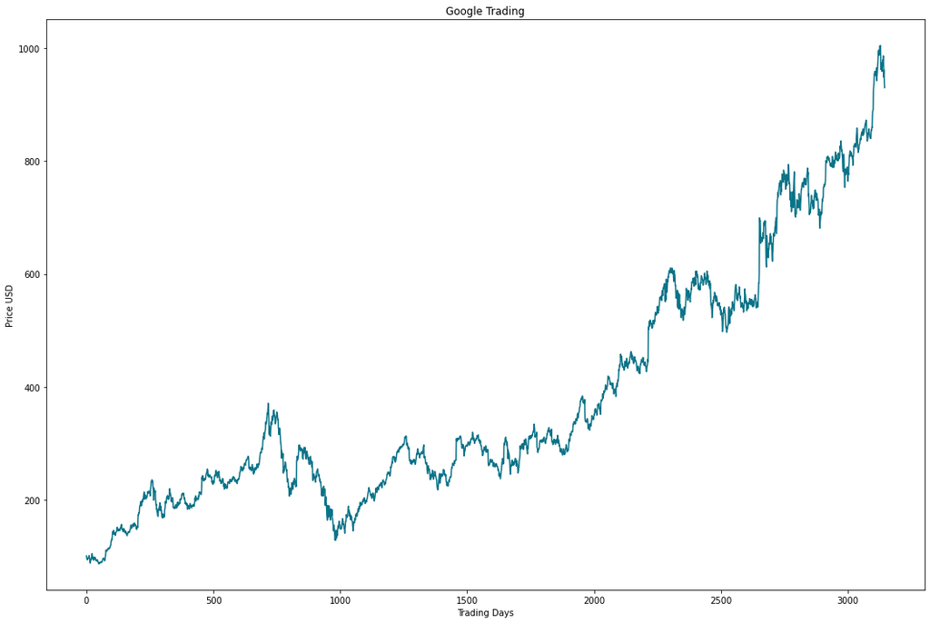

```python
import visualize

visualize.plot_basic(stocks)
```

**Step 3 :** Normalise the data using minmaxscaler function

```python
stocks = ppd.get_normalised_data(stocks)
print(stocks.head())

print("\n")
print("Open   --- mean :", np.mean(stocks['Open']),  "  \t Std: ", np.std(stocks['Open']),  "  \t Max: ", np.max(stocks['Open']),  "  \t Min: ", np.min(stocks['Open']))
print("Close  --- mean :", np.mean(stocks['Close']), "  \t Std: ", np.std(stocks['Close']), "  \t Max: ", np.max(stocks['Close']), "  \t Min: ", np.min(stocks['Close']))
print("Volume --- mean :", np.mean(stocks['Volume']),"  \t Std: ", np.std(stocks['Volume']),"  \t Max: ", np.max(stocks['Volume']),"  \t Min: ", np.min(stocks['Volume']))
```

```
   Item      Open     Close    Volume
0     0  0.012052  0.015135  0.381427
1     1  0.014234  0.010652  0.330314
2     2  0.009898  0.010112  0.195223
3     3  0.010787  0.007404  0.247858
4     4  0.008366  0.010297  0.230133


Open   --- mean : 0.3211602380317534   	 Std:  0.23258963651451448   	 Max:  1.0000000000000002   	 Min:  0.0
Close  --- mean : 0.32151990044915796   	 Std:  0.23280189369754026   	 Max:  1.0   	 Min:  0.0
Volume --- mean : 0.09001593340362025   	 Std:  0.09805864553555112   	 Max:  1.0   	 Min:  0.0
```

**Step 4 :** Visualize the data

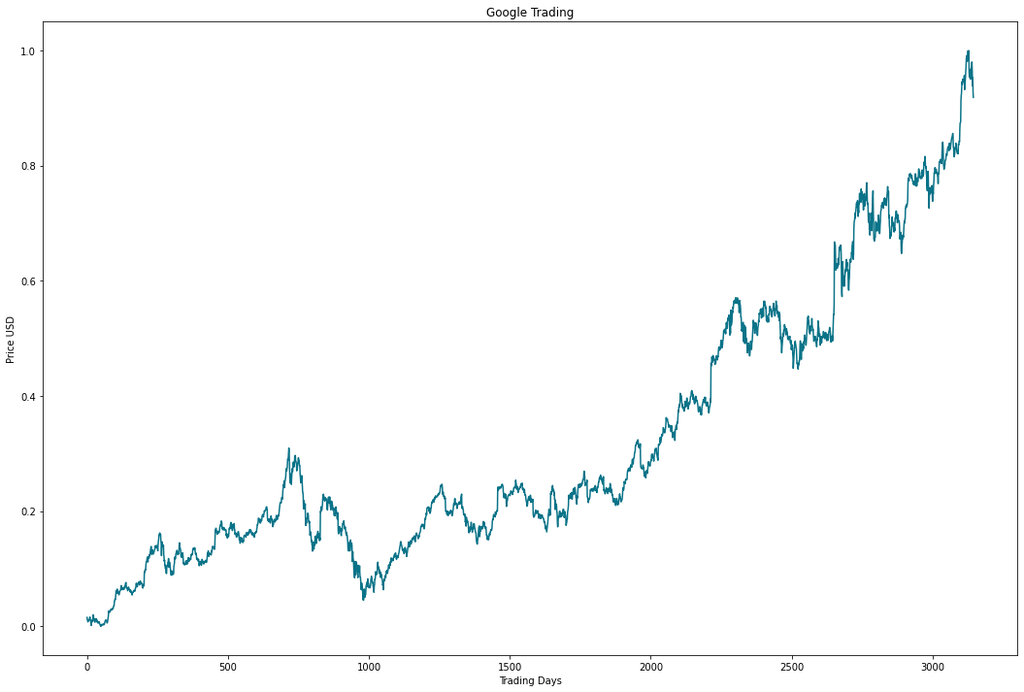

```python
visualize.plot_basic(stocks)
```

**Step 5:** Save the normalised data

```python
stocks.to_csv('google_preprocessed.csv',index= False)
```

## Bench Mark Model

In this section we will check our bench mark model which will be a simple linear regression model

**Step 1:** Load the preprocessed data

```python
import math
import pandas as pd
import numpy as np
from IPython.display import display
from sklearn import linear_model
from sklearn.model_selection import train_test_split
from sklearn.metrics import mean_squared_error
from sklearn.model_selection import TimeSeriesSplit

import visualize as vs
import stock_data as sd
import Linear_Regression_Model

stocks = pd.read_csv('google_preprocessed.csv')
display(stocks.head())
```

|  | Item | Open | Close | Volume |
| --- | --- | --- | --- | --- |
| 0 | 0 | 0.012052 | 0.015135 | 0.381427 |
| 1 | 1 | 0.014234 | 0.010652 | 0.330314 |
| 2 | 2 | 0.009898 | 0.010112 | 0.195223 |
| 3 | 3 | 0.010787 | 0.007404 | 0.247858 |
| 4 | 4 | 0.008366 | 0.010297 | 0.230133 |

**Step 2:** Split data into train and test pair

```python
X_train, X_test, y_train, y_test, label_range= sd.train_test_split_linear_regression(stocks)

print("x_train", X_train.shape)
print("y_train", y_train.shape)
print("x_test", X_test.shape)
print("y_test", y_test.shape)
```

```
x_train (2156, 1)
y_train (2156, 1)
x_test (990, 1)
y_test (990, 1)
```

**Step 3:** Train a Linear regressor model on training set and get prediction

```python
model = Linear_Regression_Model.build(X_train,y_train)
```

**Step 4:** Get prediction on test set

```python
predictions = Linear_Regression_Model.predict_prices(model,X_test, label_range)
```

**Step 5:** Plot the predicted values against actual

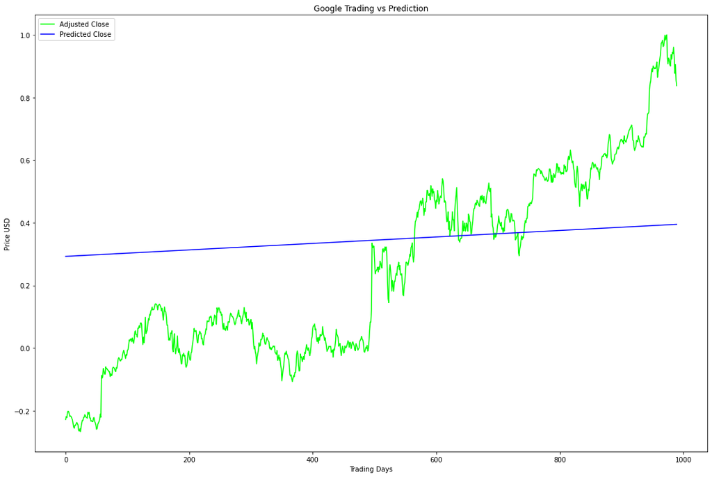

```python
vs.plot_prediction(y_test,predictions)
```

**Step 6:** measure accuracy of the prediction

```python
trainScore = mean_squared_error(X_train, y_train)
print('Train Score: %.4f MSE (%.4f RMSE)' % (trainScore, math.sqrt(trainScore)))

testScore = mean_squared_error(predictions, y_test)
print('Test Score: %.8f MSE (%.8f RMSE)' % (testScore, math.sqrt(testScore)))
```

```
Train Score: 0.1853 MSE (0.4304 RMSE)
Test Score: 0.08133962 MSE (0.28520102 RMSE)
```

## Long-Sort Term Memory Model

In this section we will use LSTM to train and test on our data set.

### Basic LSTM Model

First lets make a basic LSTM model.

**Step 1 :** import keras libraries for smooth implementaion of lstm

```python
import math
import pandas as pd
import numpy as np
from IPython.display import display

from keras.layers.core import Dense, Activation, Dropout
from keras.layers.recurrent import LSTM
from keras.models import Sequential
from keras.metrics import mean_squared_error
from sklearn.model_selection import StratifiedKFold

import lstm, time #helper libraries

import visualize as vs
import stock_data as sd
import Linear_Regression_Model

stocks = pd.read_csv('google_preprocessed.csv')
stocks_data = stocks.drop(['Item'], axis =1)

display(stocks_data.head())
```

|  | Open | Close | Volume |
| --- | --- | --- | --- |
| 0 | 0.012052 | 0.015135 | 0.381427 |
| 1 | 0.014234 | 0.010652 | 0.330314 |
| 2 | 0.009898 | 0.010112 | 0.195223 |
| 3 | 0.010787 | 0.007404 | 0.247858 |
| 4 | 0.008366 | 0.010297 | 0.230133 |

**Step 2 :** Split train and test data sets and Unroll train and test data for lstm model

```python
X_train, X_test,y_train, y_test = sd.train_test_split_lstm(stocks_data, 5)

unroll_length = 50
X_train = sd.unroll(X_train, unroll_length)
X_test = sd.unroll(X_test, unroll_length)
y_train = y_train[-X_train.shape[0]:]
y_test = y_test[-X_test.shape[0]:]

print("x_train", X_train.shape)
print("y_train", y_train.shape)
print("x_test", X_test.shape)
print("y_test", y_test.shape)
```

```
x_train (2590, 50, 3)
y_train (2590,)
x_test (446, 50, 3)
y_test (446,)
```

**Step 3 :** Build a basic Long-Short Term Memory model

```python
# build basic lstm model
model = lstm.build_lstm(input_dim = X_train.shape[-1],output_dim = unroll_length, return_sequences=True)

# Compile the model
start = time.time()
model.compile(loss='mean_squared_error', optimizer='adam')
print('compilation time : ', time.time() - start)
```

```
compilation time :  0.014991521835327148
```

**Step 4:** Train the model

```python
model.fit(
    X_train,
    y_train,
    epochs=1,
    validation_split=0.05)
```

```
<keras.callbacks.History at 0x7fd3969ce5d0>
```

**Step 5:** make prediction using test data and plot the results

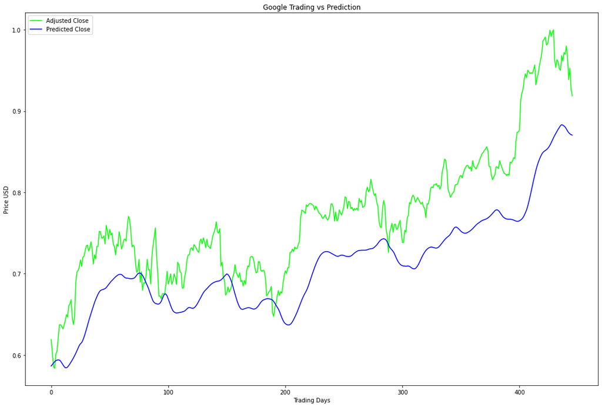

```python
predictions = model.predict(X_test)
vs.plot_lstm_prediction(y_test,predictions)
```

**Step 7:** Get the test score.

```python
trainScore = model.evaluate(X_train, y_train, verbose=0)
print('Train Score: %.8f MSE (%.8f RMSE)' % (trainScore, math.sqrt(trainScore)))

testScore = model.evaluate(X_test, y_test, verbose=0)
print('Test Score: %.8f MSE (%.8f RMSE)' % (testScore, math.sqrt(testScore)))
```

```
Train Score: 0.00039556 MSE (0.01988860 RMSE)
Test Score: 0.00475653 MSE (0.06896763 RMSE)
```